# Modelo de supervivencia

Gerardo Martín

2024-02-06

```r
datos <- read.csv("Nicho/Datos-HeV/HeV-survival.csv")

d.4 <- subset(datos, Temp == 4)
d.22 <- subset(datos, Temp == 22)
d.56 <- subset(datos, Temp == 56)
```

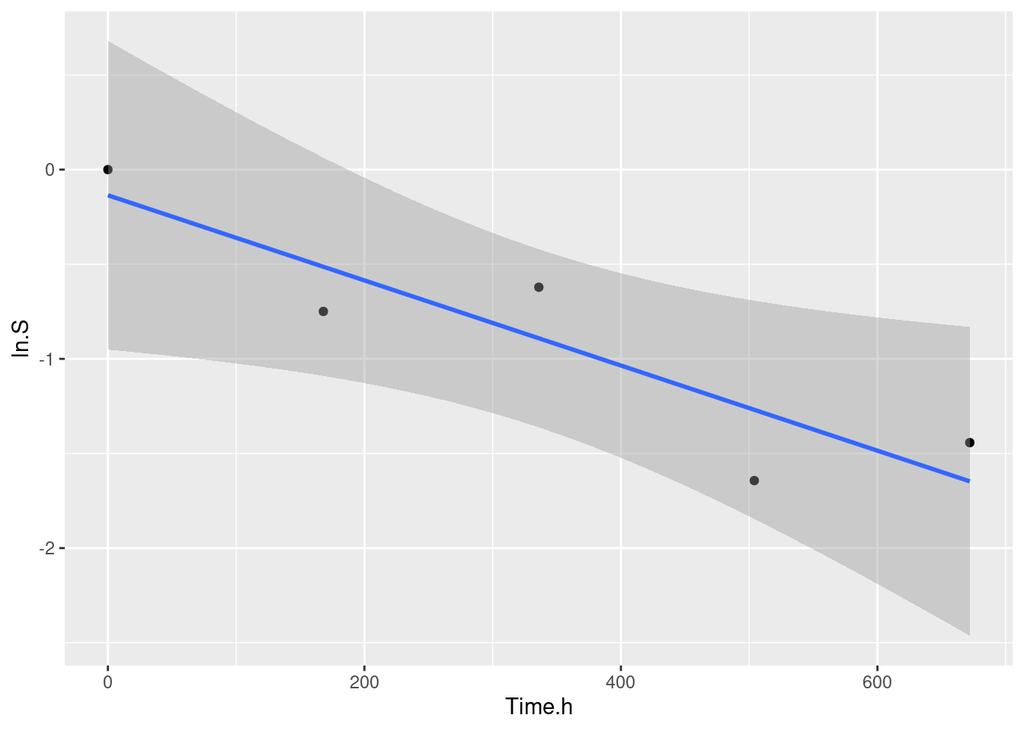

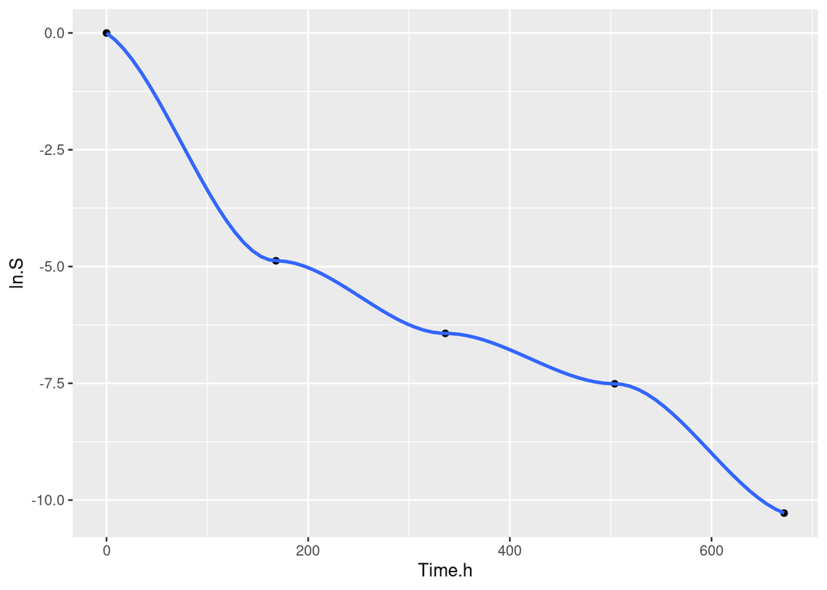

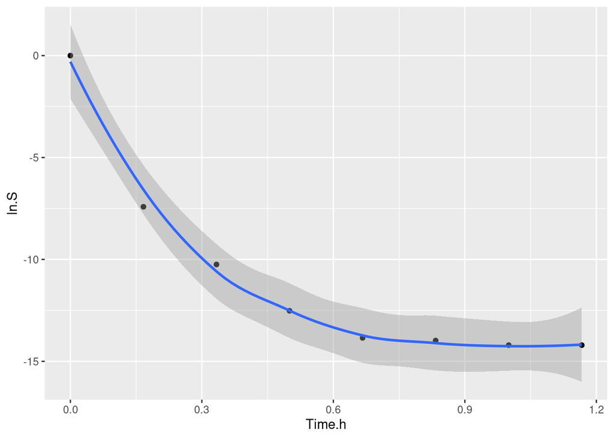

## Estimando los parámetros de la distribución Weibull

La función de distribución acumulativa del modelo Weibull es:

$$S(t) = \exp \left ( - (\rho t)^\kappa \right)$$

Para facilitar la rutina de optimización, analizaremos:

$$\log S(t) = - (\rho t)^\kappa$$
Para cada temperatura por separado con `nls`, una rutina de optimización para regresiones no lineales. Al igual que con `lm`, en `nls` tenemos que proporcionar la fórmula del modelo, el objeto que contiene los datos y en esta ocasión, una propuesta de los valores posibles de los parámetros. Esto es necesario porque `nls` funciona de manera iterativa, resolviendo el modelo primero con los valores propuestos y con unos nuevos hasta encontrar la “cima” de la función de verosimilitud que corresponde a las coordenadas de parámetros que disminuyen la diferencia entre los datos y las predicciones del modelo.

```r
m4 <- nls(ln.S ~ -( rho * Time.h )^ (kappa),
          data = d.4,
          start = list(rho = 1, kappa = 0.9),
          lower = c(0.00001, 0.1),
          upper = c(1, 1),
          algorithm =  "port")

m22 <- nls(ln.S ~ -( rho * Time.h )^ (kappa),
          data = d.22,
          start = list(rho = 1, kappa = 0.9),
          lower = c(0.0001, 0.1),
          upper = c(1, 1),
          algorithm =  "port")

m56 <- nls(ln.S ~ -( rho * Time )^ (kappa),
          data = d.56,
          start = list(rho = 1, kappa = 0.9),
          lower = c(0.1, 0.1),
          upper = c(105, 1.5),
          algorithm =  "port")
```

Una vez ajustados los modelos para cada temperatura, extraeremos los valores estimados para cada parámetro y veremos cómo los valores cambian con la temperatura:

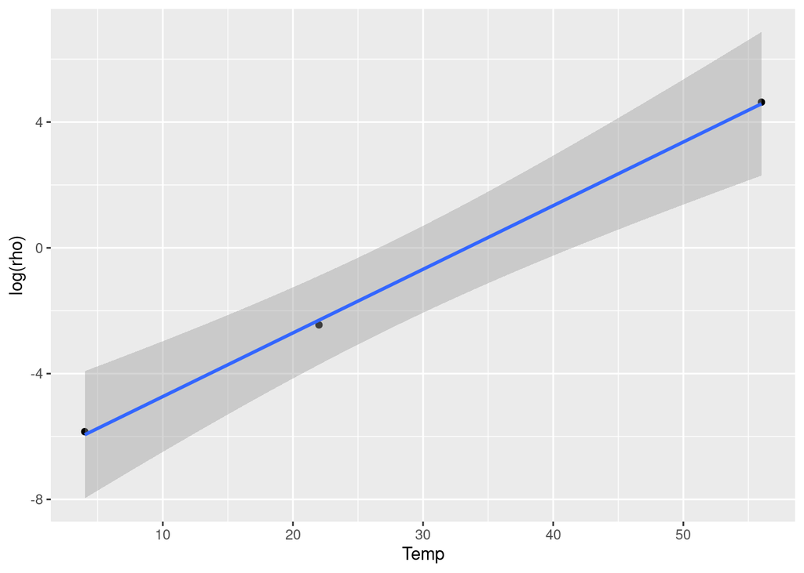

```r
par.estim <- data.frame(rbind(coef(m4), coef(m22), coef(m56)))

par.estim$Temp <-c(4, 22, 56)

ggplot(par.estim) + geom_point(aes(x = Temp, y = log(rho))) +
  geom_smooth(aes(x = Temp, y = log(rho)), method = "lm")
```

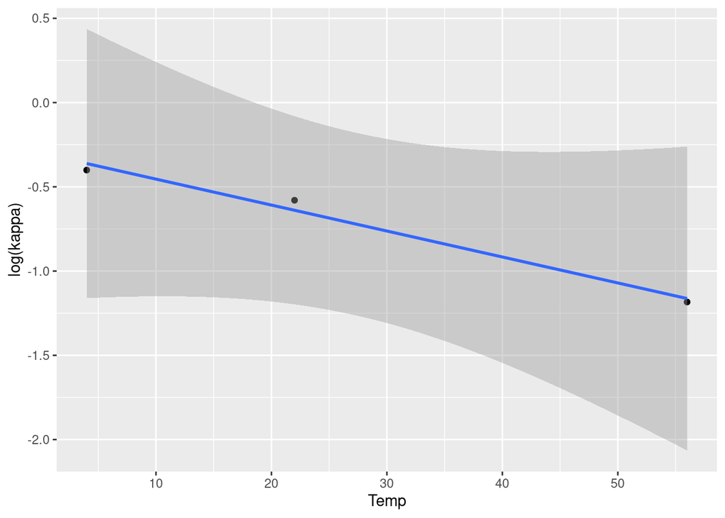

```r
ggplot(par.estim) + geom_point(aes(x = Temp, y = log(kappa))) +
  geom_smooth(aes(x = Temp, y = log(kappa)), method = "lm")
```

Para finalizar nuestro modelo, ahora ajustaremos un modelo para convertir los parámetros $\rho$ y $\kappa$ en funciones de la temperatura:

```r
m.rho <- lm(log(rho) ~ Temp, data = par.estim)
m.kappa <- lm(log(kappa) ~ Temp + Temp^2, data = par.estim)

rho.coef <- coef(m.rho)
kappa.coef <- coef(m.kappa)

coef.pk <- data.frame(par = c("ap", "Bp", "ak", "Bk"),
                      valor = c(rho.coef, kappa.coef))
```

| par | valor |
| --- | --- |
| ap | -6.7525636 |
| Bp | 0.2023745 |
| ak | -0.3002307 |
| Bk | -0.0154061 |

Con estos análisis obtenemos el modelo Weibull modificado para que sus parámetros sean funciones de la temperatura:

## Ajustando el modelo completo

Debido a lo complejo de proponer tantos parámetros para el modelo, hemos decidido ajustar modelos separdos, uno para cada temperatura y otros para cada parámetro, no obstante, lo más recomendable es ajustar el modelo completo, y utilizaremos los valores estimados para proponer los valores iniciales de a rutina de optimización:

```r
pars <- as.list(coef.pk$valor)
names(pars) <- coef.pk$par
mod <- nls(ln.S ~ -(exp(ap  + Bp * Temp) * Time.h)^exp(ak + Bk * Temp),
           data = datos,
           start = pars,
           lower = c(-12, 0, -1, -0.05),
           upper = c(-3, 0.5, 0.1, 0.1),
           algorithm = "port")
summary(mod)
```

```
##
## Formula: ln.S ~ -(exp(ap + Bp * Temp) * Time.h)^exp(ak + Bk * Temp)
##
## Parameters:
##     Estimate Std. Error t value Pr(>|t|)
## ap -7.203110   0.756712  -9.519 1.71e-07 ***
## Bp  0.278113   0.023384  11.893 1.05e-08 ***
## ak -0.732855   0.151775  -4.829 0.000268 ***
## Bk -0.007276   0.003243  -2.244 0.041531 *
## ---
## Signif. codes:  0 '***' 0.001 '**' 0.01 '*' 0.05 '.' 0.1 ' ' 1
##
## Residual standard error: 0.6706 on 14 degrees of freedom
##
## Algorithm "port", convergence message: relative convergence (4)
```

Y guardamos los resultados

```r
coef.mod <- data.frame(par = names(pars),
                       valor = coef(mod))

write.csv(coef.mod, "Nicho/Coeficientes-pk.csv")
```

## Representación gráfica del modelo

Para ver el efecto de la temperatura sobre la supervivencia, necesitamos crear primero una tabla que contenga los tiempos y temperaturas para sustituir en el modelo:

```r
datos.nuevos <- expand.grid(Tiempo = seq(0, 12, len = 50),
                            Temp = seq(4, 56, len = 50))
knitr::kable(head(datos.nuevos))
```

| Tiempo | Temp |
| --- | --- |
| 0.0000000 | 4 |
| 0.2448980 | 4 |
| 0.4897959 | 4 |
| 0.7346939 | 4 |
| 0.9795918 | 4 |
| 1.2244898 | 4 |

Posteriormente, tenemos que crear una función que hará los cálculos:

```r
weib <- function(Tiempo = NA, Temp = NA, pars = NA){
  ap <- pars$ap
  Bp <- pars$Bp
  ak <- pars$ak
  Bk <- pars$Bk

  p <- exp(ap + Bp * Temp)
  k <- exp(ak + Bk * Temp)

  S <- exp(- (p * Tiempo) ^ k)
  return(S)
}
```

Con esta función ya podemos generar un gráfico que nos permita ver dicho efecto de la temperatura:

```r
pars.1 <- as.list(coef(mod))

Sup <- weib(Tiempo = datos.nuevos$Tiempo,
              Temp = datos.nuevos$Temp,
              pars = pars.1)

datos.nuevos$Sup <- Sup
```

Graficando las predicciones del modelo con `lattice`:

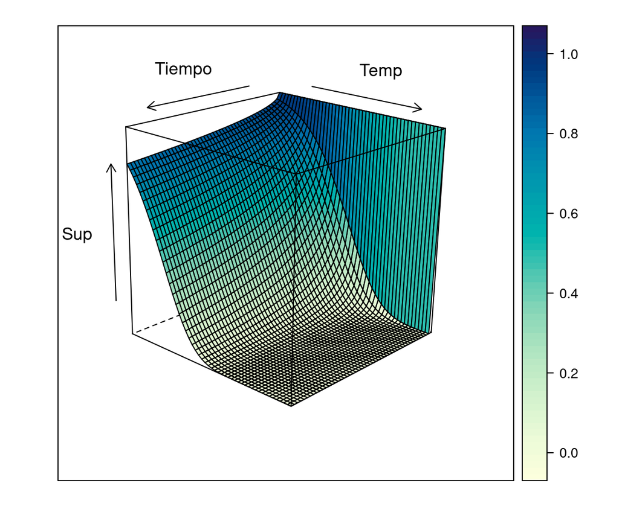

```r
library(lattice)

wireframe(Sup ~ Tiempo + Temp,
          data = datos.nuevos,
          drape = T,
          screen = list(z = -135, x = -70, y = 3))
```

# ¿Cómo representamos este modelo en el espacio?

## Escenario simple

Tomar en cuenta la temperatura promedio y resolver como se hizo arriba sustituyendo la temperatura por una capa ráster y seleccionando una serie de puntos en el tiempo para resolver.

## Escenario más realista

$$T(t) = T_{min} + T_{dif}\cos²(\pi t)$$

donde $T_{min}$ es la temperatura mínima y $T_{dif}$ es la diferencia entre la temperatura mínima y máxima. Una dificultad adicional que introduce este escenario es que necesitamos convertir el modelo Weibull en una ecuación diferencial ordinaria y sustituir la temperatura como función del tiempo dentro de las ecuaciones para los parámetros $\rho$ y $\kappa$.

### Transformando el modelo Weibull en ecuación diferencial

Comencemos por diferenciar la distribución acumulativa, aplicando la regla de las funciones encadenadas:

$$\frac{d}{dx} f(g(x)) = g'(x) f'(g(x))$$
Sabemos que:

1. $f(g(x)) = \exp(-(\rho t)^\kappa)$
2. $g'(x) = -(\rho t)^\kappa$

Por lo tanto

$$\frac{dS}{dt} = - \rho \kappa(\rho t) ^{\kappa - 1} \exp(-(\rho t)^\kappa)$$

Con esto, aún no terminamos, porque necesitamos la forma implícita, de modo que $S$ aparezca de ambos lados de la ecuación. Primero sustituimos $S=\exp(-(\rho t)^\kappa)$:

$$\frac{dS}{dt} = - \rho \kappa(\rho t) ^{\kappa - 1} S$$

y para eliminar $t$ necesitamos representarla en términos de $S$:

$$t = \frac{-(\log S)^\frac{1}{\kappa}}{\rho}$$

Y terminamos sustituyendo $t$ para obtener:

$$\frac{dS}{dt} = - \left ( \rho \kappa (- \log S)^{1 - \frac{1}{\kappa}} \right) S$$

En esta versión implícita como ecuación diferenciar podemos sustituir $T(t), \rho(T), \kappa(T)$, para obtener la loquísima ecuación:

$$\frac{dS}{dt} = - \left ( (\exp(\alpha_{\rho} + \beta_{\rho} (T_{min} + T_{dif}\cos^2(\pi t))) \exp(\alpha_{\kappa} + \beta_{\kappa} (T_{min} + T_{dif}\cos^2(\pi t))) (- \log S)^{1 - \frac{1}{\exp(\alpha_{\kappa} + \beta_{\kappa} (T_{min} + T_{dif}\cos^2(\pi t)))}} \right) S$$
Fin de la parte I, regresar a la página principal del curso